# Statistical Tests

## Dataset

For this practical, we will use the **survey** dataset from the package **MASS**.

You can either load the **MASS** package to get access to this dataset

```r
library(MASS)
```

or make a copy of this data

```r
survey <- MASS::survey
```

The **survey** dataset contains responses of 237 statistics students at the University of Adelaide to a number of questions:

```r
str(survey)
```

```
## 'data.frame':    237 obs. of  12 variables:
##  $ Sex   : Factor w/ 2 levels "Female","Male": 1 2 2 2 2 1 2 1 2 2 ...
##  $ Wr.Hnd: num  18.5 19.5 18 18.8 20 18 17.7 17 20 18.5 ...
##  $ NW.Hnd: num  18 20.5 13.3 18.9 20 17.7 17.7 17.3 19.5 18.5 ...
##  $ W.Hnd : Factor w/ 2 levels "Left","Right": 2 1 2 2 2 2 2 2 2 2 ...
##  $ Fold  : Factor w/ 3 levels "L on R","Neither",..: 3 3 1 3 2 1 1 3 3 3 ...
##  $ Pulse : int  92 104 87 NA 35 64 83 74 72 90 ...
##  $ Clap  : Factor w/ 3 levels "Left","Neither",..: 1 1 2 2 3 3 3 3 3 3 ...
##  $ Exer  : Factor w/ 3 levels "Freq","None",..: 3 2 2 2 3 3 1 1 3 3 ...
##  $ Smoke : Factor w/ 4 levels "Heavy","Never",..: 2 4 3 2 2 2 2 2 2 2 ...
##  $ Height: num  173 178 NA 160 165 ...
##  $ M.I   : Factor w/ 2 levels "Imperial","Metric": 2 1 NA 2 2 1 1 2 2 2 ...
##  $ Age   : num  18.2 17.6 16.9 20.3 23.7 ...
```

## Tests for Continuous Variables

### `Age` differences

First, we want to test if there is a difference in `Age` between `Female` and `Male` students.

#### Task 1

Which statistical test do you think is appropriate to test this?

To decide, it is useful to get an impression of the distribution of the data, for example using a histogram.

The function `hist()` creates a histogram.

You need to check the distribution for each of the two groups separately.

#### Solution 1

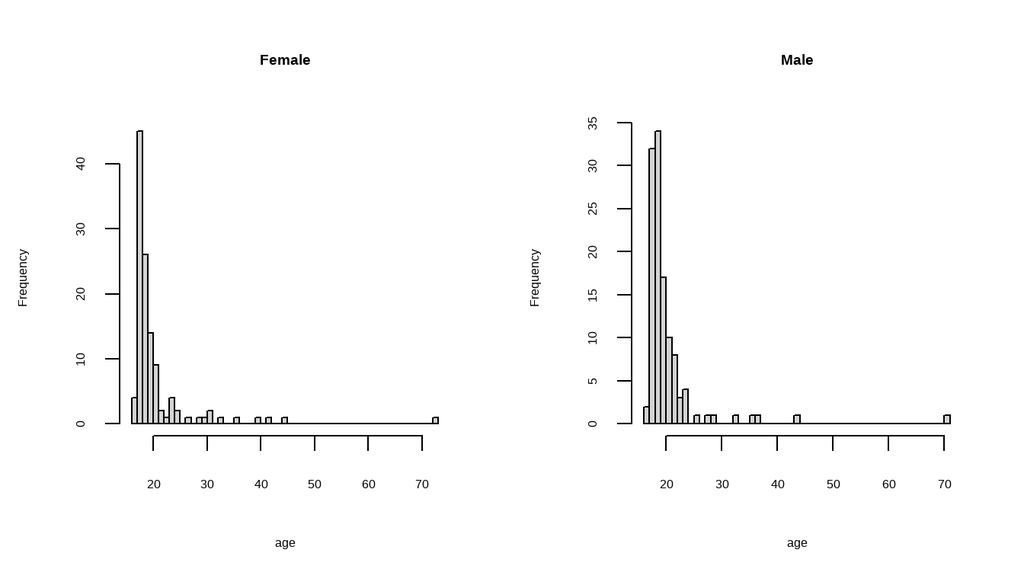

```r
par(mfrow = c(1, 2)) # arrange plots in a grid with one row and two columns
hist(survey$Age[which(survey$Sex == 'Female')], nclass = 50, main = 'Female', xlab = 'age')
hist(survey$Age[which(survey$Sex == 'Male')], nclass = 50, main = 'Male', xlab = 'age')
```

We notice that the distribution within each of the groups is skewed and does not follow a normal distribution. We decide to use a non-parametric test.

Note:

In the above syntax we used `...[which(survey$Sex == 'Female')]...` and not just `...[survey$Sex == 'Female]...`. These two ways of selecting cases give different results when there are missing values:

```r
x <- c("A", "A", "B", NA, "A", "B")
y <- c("a", "a", "b", "na_value", "a", "b")

y[x == "A"]
```

```
## [1] "a" "a" NA  "a"
```

```r
y[which(x == "A")]
```

```
## [1] "a" "a" "a"
```

#### Task 2

Perform a non-parametric test to investigate whether males are **older** than females.

[It is recommended](http://hbiostat.org/doc/bbr.pdf) to use the exact p-value calculation when possible (= when there are no ties), and to use continuity correction if a exact calculation is not possble.

You may use the `wilcox.test()` function.

To test if males are older, you need a one-sided test.

#### Solution 2

To perform a one-sided test, the argument `alternative` needs to be specified to either `"less"` or `"greater"`.

In the help file for `wilcox.test()` it is written that

> […] the one-sided alternative “greater” is that `x` is shifted to the right of `y`.

When using the formula specification, `x` refers to the first factor level (`Female` in our case) and `y` refers to the second level (`Male` in our case).

Setting `alternative = "greater"` would, hence, test the alternative hypothesis $H_1: Female > Male$. Since we want to test $H_1: Male > Female$ (i.e., $H_0: Male \leq Female$) we need to set `alternative = "less"`:

```r
wtest <- wilcox.test(Age ~ Sex, data = survey, alternative = 'less', exact = TRUE)
wtest
```

```
##
##  Wilcoxon rank sum test with continuity correction
##
## data:  Age by Sex
## W = 5869, p-value = 0.01858
## alternative hypothesis: true location shift is less than 0
```

Because there are ties in the data, the exact calculation of the p-value could not be used and the normal approximation was used instead. Continuity correction was used (by default).

The output shows that we can reject the null hypothesis that males are younger than (or equally as old as) females, i.e., males are likely older.

### Differences in the span of both hands

Next, we would like to test if the span of the writing hand (`Wr.Hnd`; distance from tip of thumb to tip of little finger) differs from the span of the non-writing hand (`NW.Hnd`).

#### Task 1

Make a plot to investigate if a `t.test()` would be appropriate to answer this question.

#### Solution 1

We are now investigating a paired sample and are, therefore, interested in the difference between the spans of the writing and non-writing hand. (Remember: a paired t-test is the same as a one-sample t-test of the differences)

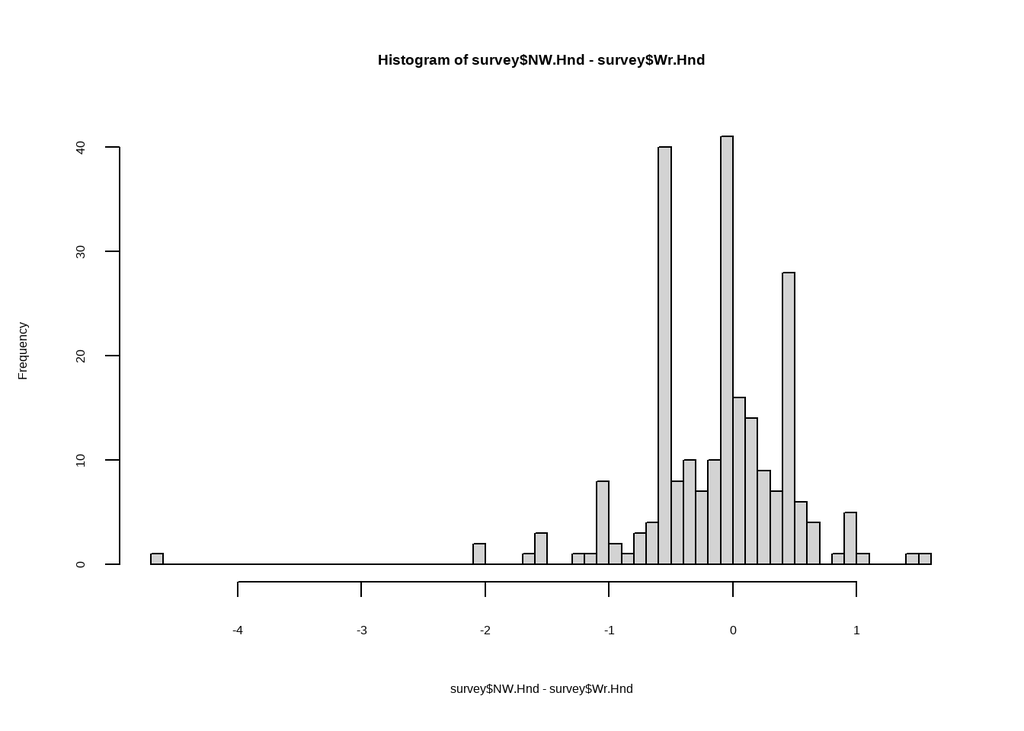

```r
hist(survey$NW.Hnd - survey$Wr.Hnd, nclass = 50)
```

#### Task 2

- Perform a `t.test()` to answer our research question about the spand of the hands.
- Confirm that the paired t-test and the one sample t-test do indeed give the same result.

#### Solution 2

```r
# one-sample t-test:
ttest1 <- t.test(survey$Wr.Hnd - survey$NW.Hnd)

# paired t-test:
ttest2 <- t.test(survey$Wr.Hnd, survey$NW.Hnd, paired = TRUE)

ttest1
```

```
##
##  One Sample t-test
##
## data:  survey$Wr.Hnd - survey$NW.Hnd
## t = 2.1268, df = 235, p-value = 0.03448
## alternative hypothesis: true mean is not equal to 0
## 95 percent confidence interval:
##  0.006367389 0.166513967
## sample estimates:
##  mean of x
## 0.08644068
```

```r
ttest2
```

```
##
##  Paired t-test
##
## data:  survey$Wr.Hnd and survey$NW.Hnd
## t = 2.1268, df = 235, p-value = 0.03448
## alternative hypothesis: true difference in means is not equal to 0
## 95 percent confidence interval:
##  0.006367389 0.166513967
## sample estimates:
## mean of the differences
##              0.08644068
```

#### Task 3

In the previous solution(s) we have used the default options for several of the arguments.

- Which default options were used in the one-sample t-test?
- Are these default options appropriate in this case?

To see the default options of a function, check the help file (`?t.test`).

#### Solution 3

In the help file we can read:

```r
## Default S3 method:
t.test(x, y = NULL,
       alternative = c("two.sided", "less", "greater"),
       mu = 0, paired = FALSE, var.equal = FALSE,
       conf.level = 0.95, ...)
```

The default values that were used are:

- `y = NULL` (correct, because we are doing a one-sample test)
- `alternative = "two.sided"` (correct, we want to test for difference in either direction)
- `mu = 0` (correct, we want to test for any difference)
- `paired = FALSE` (only needs to be specified when we use both arguments `x` and `y`)
- `var.equal = FALSE` (only relevant for independent samples test)
- `conf.level = 0.95` (OK, since this is a common choice and nothing else was specified in the exercise)

## Testing Categorical Variables

### Left vs Right

We now want to test if the writing hand (`W.Hnd`) is associated with which hand was on top when the students clapped their hands (`Clap`).

#### Task 1

Perform an appropriate test.

#### Solution 1

```r
chisq.test(table(survey$W.Hnd, survey$Clap))
```

```
##
##  Pearson's Chi-squared test
##
## data:  table(survey$W.Hnd, survey$Clap)
## X-squared = 19.252, df = 2, p-value = 6.598e-05
```

Note:

A common recommendation is / used to be that Fisher’s Exact test should be used instead of the $\chi^2$-test whenever one of the expected frequencies is $< 5$, however this “cut-off” is arbitrary (https://doi.org/10.1002/sim.2832) and a $\chi^2$-test can be used.

#### Task 2

Check if the conclusion differs when we take into account the students’ `Sex`.

Consider `Sex` as stratifying variable.

#### Solution 2

To test for an association between `W.Hnd` and `Clap` in each of the two strata defined by `Sex` we can use the `mantelhaen.test()`:

```r
MHtest <- mantelhaen.test(table(survey$W.Hnd, survey$Clap, survey$Sex))
MHtest
```

```
##
##  Cochran-Mantel-Haenszel test
##
## data:  table(survey$W.Hnd, survey$Clap, survey$Sex)
## Cochran-Mantel-Haenszel M^2 = 19.922, df = 2, p-value = 4.721e-05
```

## Multiple Testing

### Task

Obtain adjusted p-values for these test and perform a multiplicity correction:

- Wilcoxon rank sum test for `Age` by `Sex`
- t-test for the difference between the `Wr.Hnd` and `NW.Hnd`
- Mantel-Haenszel test for `W.Hnd`, `Clap` and `Sex`

Adjusted p-values can be obtained using the function `p.adjust()`.

### Solution

```r
pvals <- c(wtest = wtest$p.value,
           ttest = ttest1$p.value,
           MHtest = MHtest$p.value)

padj <- p.adjust(pvals, method = "BH")
padj
```

```
##        wtest        ttest       MHtest
## 0.0278728964 0.0344813844 0.0001416164
```

Note:

To make a nice looking comparison we could use the following syntax:

```r
data.frame('p-value' = format.pval(pvals, eps = 0.001, digits = 2),
           'adj.p-value' = format.pval(padj, eps = 0.001, digits = 2),
           row.names = names(pvals), check.names = FALSE
)
```

```
##        p-value adj.p-value
## wtest    0.019       0.028
## ttest    0.034       0.034
## MHtest  <0.001      <0.001
```

By setting the argument `check.names = FALSE` in `data.frame()` we prevent that R “cleanes” the variable names (replaces the “-” with “.”, because a “-” in a variable name is usually rather inconvenient and can give problems.).

The argument `eps` in `format.pval()` controls the cutoff at which the “<…” notation is used, the argument `digits` sets the number of significant digits are used (significant has nothing to do with statistical significance in this case).

© Nicole Erler